# E-Commerce Fraud Detection: Baseline Model Development

This notebook implements baseline models for detecting fraudulent transactions in the e-commerce dataset.

## 1. Setup and Data Loading

First, let's import the necessary libraries and load our preprocessed data.

```python
# Import libraries
from pathlib import Path
import numpy as np
import pandas as pd
import matplotlib.pyplot as plt
import seaborn as sns
import os
import sys
import warnings
from sklearn.model_selection import train_test_split, cross_val_score, StratifiedKFold
from sklearn.metrics import classification_report, confusion_matrix, roc_curve, precision_recall_curve
from sklearn.preprocessing import StandardScaler
from imblearn.over_sampling import SMOTE
from imblearn.pipeline import Pipeline as ImbPipeline
from sklearn.ensemble import RandomForestClassifier
from sklearn.linear_model import LogisticRegression
from sklearn.tree import DecisionTreeClassifier
from sklearn.svm import SVC
from sklearn.neighbors import KNeighborsClassifier
from sklearn.neural_network import MLPClassifier
from sklearn.preprocessing import StandardScaler, MinMaxScaler
from sklearn.model_selection import train_test_split, GridSearchCV, cross_val_score
from sklearn.metrics import (
    accuracy_score,
    precision_score,
    recall_score,
    f1_score,
    roc_auc_score,
    average_precision_score,
    confusion_matrix,
    classification_report,
    precision_recall_curve,
    roc_curve
)
# Import custom modules
# Add the project source to path
sys.path.append('../')
from src.data.preprocessing_train import process_data_pipeline_optimized
from src.data.preprocessing import process_data_pipeline

from src.visualization.visualization import plot_correlation_heatmap, set_visualization_style
from src.models.baseline import (
    train_baseline_model, evaluate_model, print_evaluation_report,
    plot_confusion_matrix, plot_roc_curve, plot_precision_recall_curve,
    save_model, get_feature_importance, plot_feature_importance
)
from src.utils.utils import (
    get_data_path, get_models_path, save_figure, save_results, timer
)

# Ignore warnings
warnings.filterwarnings('ignore')
set_visualization_style()

# Set plotting style
plt.style.use('ggplot')
sns.set_style("whitegrid")
sns.set_context("notebook", font_scale=1.2)
%matplotlib inline
```

```python
# import torch

# # Load the data
# data_path = get_data_path()
# file_paths = [
#     os.path.join(data_path, 'Fraudulent_E-Commerce_Transaction_Data.csv'),
#     os.path.join(data_path, 'Fraudulent_E-Commerce_Transaction_Data_2.csv')
# ]

# # For initial model development, we'll use the smaller dataset
# # In production, you would use the full dataset
# df = load_data(file_paths[1])
# print(f"Loaded dataset with {df.shape[0]} rows and {df.shape[1]} columns.")

# # Clean and preprocess
# df_cleaned = clean_data(df)
# df_engineered = engineer_features(df_cleaned)

# # Display the first few rows to verify preprocessing
# df_engineered.head()
```

## 2. Prepare Data for Modeling

Now, let's split our data into features and target, and prepare it for model training.

```python
# Get the project's root directory
current_dir = Path().absolute()
root_dir = current_dir.parent if 'notebooks' in str(current_dir) else current_dir
print(f"Project root directory: {root_dir}")
```

```
Project root directory: /home/zahemen/projects/ML/ecomm-fraud-detection
```

```python
df_example = pd.read_csv(root_dir / 'data/Fraudulent_E-Commerce_Transaction_Data_2.csv')

df_example.info(memory_usage='deep')
```

```
<class 'pandas.core.frame.DataFrame'>
RangeIndex: 23634 entries, 0 to 23633
Data columns (total 16 columns):
 #   Column              Non-Null Count  Dtype
---  ------              --------------  -----
 0   Transaction ID      23634 non-null  object
 1   Customer ID         23634 non-null  object
 2   Transaction Amount  23634 non-null  float64
 3   Transaction Date    23634 non-null  object
 4   Payment Method      23634 non-null  object
 5   Product Category    23634 non-null  object
 6   Quantity            23634 non-null  int64
 7   Customer Age        23634 non-null  int64
 8   Customer Location   23634 non-null  object
 9   Device Used         23634 non-null  object
 10  IP Address          23634 non-null  object
 11  Shipping Address    23634 non-null  object
 12  Billing Address     23634 non-null  object
 13  Is Fraudulent       23634 non-null  int64
 14  Account Age Days    23634 non-null  int64
 15  Transaction Hour    23634 non-null  int64
dtypes: float64(1), int64(5), object(10)
memory usage: 19.2 MB
```

```python
cat_cols = df_example.select_dtypes(include=['object']).columns.tolist()
for col in cat_cols:
    print(f"{col} \t\t->\t\t {df_example[col].nunique()} unique values")
```

```
Transaction ID 		->		 23634 unique values
Customer ID 		->		 23634 unique values
Transaction Date 		->		 23607 unique values
Payment Method 		->		 4 unique values
Product Category 		->		 5 unique values
Customer Location 		->		 14868 unique values
Device Used 		->		 3 unique values
IP Address 		->		 23634 unique values
Shipping Address 		->		 23634 unique values
Billing Address 		->		 23634 unique values
```

```python
# # Same function call, but now much faster
# X_train, X_test, y_train, y_test = process_data_pipeline([
#     root_dir / 'data/Fraudulent_E-Commerce_Transaction_Data_2.csv',
# ])
```

```python
X_train_large, X_test_large, y_train_large, y_test_large = process_data_pipeline([
    root_dir / 'data/Fraudulent_E-Commerce_Transaction_Data.csv',
], subset_percentage=10) #Take 15% of the data for faster processing
```

```
Starting data processing pipeline...

STEP 1: Loading and merging data...
Loaded dataset with 1472952 records and 16 columns

Taking a 10% stratified subset of the data...
Original dataset: 1472952 samples, 73838 fraudulent (5.01%)
Subset: 147295 samples, 7384 fraudulent (5.01%)

STEP 2: Cleaning data...
Cleaning dataset with 147295 records...
Data cleaning completed in 0.16 seconds

STEP 3: Engineering features...
Engineering features for 147295 records...
Processing time features in 30 parallel batches...
```

```
Transforming addresses...
Transforming 147295 addresses to Ghanaian format...
Processing 148 batches in parallel using 11 workers...
```

```
Address transformation completed in 8471.30 seconds
Feature engineering completed in 8473.19 seconds

STEP 4: Preparing data for modeling...
Preparing data for modeling (280089 records)...
Warning: Found 132794 NaN values in the target column 'Is Fraudulent'
Dropped 132794 rows with NaN target values. 147295 rows remaining.
Applying ordinal encoding to 1 columns...
One-hot encoding in 30 parallel chunks using 11 workers...
```

```
Data preparation completed in 1.27 seconds
Final processed dataset has 23 features after encoding

STEP 5: Splitting into train/test sets...

Entire data pipeline completed in 8484.36 seconds
Train set: 117836 samples, Test set: 29459 samples
```

```python
import pickle
import joblib
from pathlib import Path

# Import necessary libraries

# Create a directory to store the serialized datasets
data_cache_dir = root_dir / 'data' / 'processed'
data_cache_dir.mkdir(exist_ok=True, parents=True)

# # Save using pickle (good for general purposes)
# with open(data_cache_dir / 'train_test_data_large.pkl', 'wb') as f:
#     pickle.dump({
#         'X_train': X_train_large,
#         'y_train': y_train_large,
#         'X_test': X_test_large,
#         'y_test': y_test_large
#     }, f)

# Alternatively, use joblib (better for large numpy arrays)
joblib.dump({
    'X_train': X_train_large,
    'y_train': y_train_large,
    'X_test': X_test_large,
    'y_test': y_test_large
}, data_cache_dir / 'train_test_data_large.joblib')

print(f"Data saved to {data_cache_dir}")
print(f"To load: use pickle.load(open('{data_cache_dir}/train_test_data_large.pkl', 'rb'))")
```

```
Data saved to /home/zahemen/projects/ML/ecomm-fraud-detection/data/processed
To load: use pickle.load(open('/home/zahemen/projects/ML/ecomm-fraud-detection/data/processed/train_test_data_large.pkl', 'rb'))
```

```python
import joblib

# Load the saved data from joblib file

# Load data from the joblib file
data_cache_dir = root_dir / 'data' / 'processed'
data = joblib.load(data_cache_dir / 'train_test_data_large.joblib')

# Extract data into variables
X_train_large = data['X_train']
y_train_large = data['y_train']
X_test_large = data['X_test']
y_test_large = data['y_test']

print(f"Data loaded successfully from {data_cache_dir / 'train_test_data_large.joblib'}")
print(f"X_train shape: {X_train_large.shape}")
print(f"y_train shape: {y_train_large.shape}")
print(f"X_test shape: {X_test_large.shape}")
print(f"y_test shape: {y_test_large.shape}")

# Check class distribution in loaded data
print("\nClass distribution in training set:")
print(y_train_large.value_counts())
print(f"Fraud rate in training data: {y_train_large.mean() * 100:.2f}%")
```

```
Data loaded successfully from /home/zahemen/projects/ML/ecomm-fraud-detection/data/processed/train_test_data_large.joblib
X_train shape: (117836, 23)
y_train shape: (117836,)
X_test shape: (29459, 23)
y_test shape: (29459,)

Class distribution in training set:
Is Fraudulent
0.0    111929
1.0      5907
Name: count, dtype: int64
Fraud rate in training data: 5.01%
```

```python
# Check dimensions of train/test splits
print(f"X_train shape: {X_train_large.shape}")
print(f"X_test shape: {X_test_large.shape}")
print(f"y_train shape: {y_train_large.shape}")
print(f"y_test shape: {y_test_large.shape}")

# Check class imbalance
print("\nClass distribution in training set:")
print(y_train_large.value_counts())
print(f"Fraud rate in training data: {y_train_large.mean() * 100:.2f}%")

print("\nClass distribution in test set:")
print(y_test_large.value_counts())
print(f"Fraud rate in test data: {y_test_large.mean() * 100:.2f}%")

# Check feature summary statistics for both splits
print("\nFeature statistics (train set):")
display(X_train_large.describe())


# Define variable X for later use in the notebook
X = X_train_large.copy()
y = y_train_large.copy()
```

```
X_train shape: (117836, 23)
X_test shape: (29459, 23)
y_train shape: (117836,)
y_test shape: (29459,)

Class distribution in training set:
Is Fraudulent
0.0    111929
1.0      5907
Name: count, dtype: int64
Fraud rate in training data: 5.01%

Class distribution in test set:
Is Fraudulent
0.0    27982
1.0     1477
Name: count, dtype: int64
Fraud rate in test data: 5.01%

Feature statistics (train set):
```

|  | Transaction Amount | Quantity | Customer Age | Customer Location | Account Age Days | Transaction Hour | Amount_per_Item | Same_Address | Transaction Day | Transaction Month | Transaction Year | Transaction DayOfWeek | Is Weekend | Transaction_Recency_Days |
| --- | --- | --- | --- | --- | --- | --- | --- | --- | --- | --- | --- | --- | --- | --- |
| count | 117836.000000 | 117836.000000 | 117836.000000 | 117836.000000 | 117836.000000 | 117836.000000 | 117836.000000 | 117836.000000 | 117836.000000 | 117836.000000 | 117836.0 | 117836.000000 | 117836.000000 | 117836.000000 |
| mean | 227.265119 | 3.001332 | 34.486642 | 25700.941996 | 179.656650 | 11.298440 | 103.807417 | 0.900633 | 15.342756 | 2.047693 | 2024.0 | 2.955217 | 0.280958 | 46.215155 |
| std | 266.022514 | 1.416207 | 9.997099 | 14858.714240 | 107.024748 | 6.971997 | 157.555457 | 0.299155 | 8.929321 | 0.872477 | 0.0 | 2.011539 | 0.449469 | 26.976819 |
| min | 10.000000 | 1.000000 | -8.000000 | 0.000000 | 1.000000 | 0.000000 | 2.002000 | 0.000000 | 1.000000 | 1.000000 | 2024.0 | 0.000000 | 0.000000 | 0.000000 |
| 25% | 68.850000 | 2.000000 | 28.000000 | 13306.000000 | 86.000000 | 5.000000 | 23.875750 | 1.000000 | 8.000000 | 1.000000 | 2024.0 | 1.000000 | 0.000000 | 23.000000 |
| 50% | 152.625000 | 3.000000 | 34.000000 | 25050.500000 | 179.000000 | 11.000000 | 56.147333 | 1.000000 | 15.000000 | 2.000000 | 2024.0 | 3.000000 | 0.000000 | 46.000000 |
| 75% | 298.095000 | 4.000000 | 41.000000 | 38690.000000 | 273.000000 | 17.000000 | 121.873500 | 1.000000 | 23.000000 | 3.000000 | 2024.0 | 5.000000 | 1.000000 | 70.000000 |
| max | 6415.200000 | 5.000000 | 80.000000 | 51605.000000 | 365.000000 | 23.000000 | 5055.250000 | 1.000000 | 31.000000 | 4.000000 | 2024.0 | 6.000000 | 1.000000 | 93.000000 |

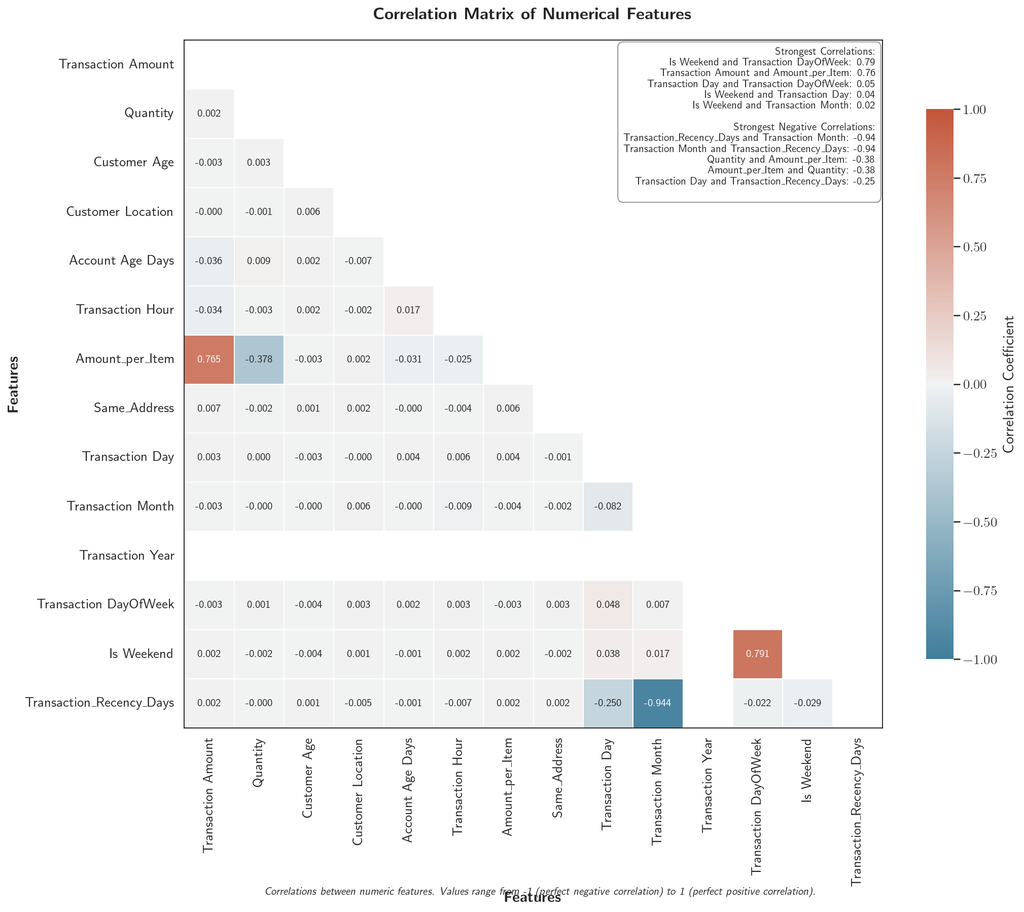

```python
# Plot correlation matrix of numerical features
fig = plot_correlation_heatmap(
    X_train_large,
    numeric_only=True,
    title="Correlation Matrix of Numerical Features",
)
```

```python
# # Prepare data for modeling
# # Use selective features to avoid memory issues
# feature_columns = [
# 	'Transaction Amount', 'Quantity', 'Customer Age', 'Account Age Days',
# 	'Transaction Hour', 'Transaction Day', 'Transaction Month',
# 	'Transaction DayOfWeek', 'Is Weekend', 'Amount_per_Item',
# 	'Same_Address', 'Transaction_Recency_Days'
# ]

# # Add categorical features with controlled one-hot encoding
# categorical_features = ['Payment Method', 'Product Category', 'Device Used']
# # Avoid high cardinality text fields like addresses, IPs, and IDs

# # Extract the target
# y = df_engineered['Is Fraudulent']

# # Extract numerical features
# X_numeric = df_engineered[feature_columns]

# # Process categorical features with limited cardinality
# X_categorical = pd.get_dummies(df_engineered[categorical_features], drop_first=True)

# # Combine features
# X = pd.concat([X_numeric, X_categorical], axis=1)

# # Display the shape of the prepared data
# print(f"Features shape: {X.shape}")
# print(f"Target shape: {y.shape}")

# # Display class distribution
# print("\nClass distribution:")
# print(y.value_counts())
# print(f"Fraud rate: {y.mean() * 100:.2f}%")
```

## 3. Baseline Model: Logistic Regression

Let's start with a logistic regression model as our baseline.

```python
@timer
def train_logistic_regression():
    """Train a logistic regression model."""
    return train_baseline_model(X_train_large, y_train_large, model_type='logistic')

# Train the model
lr_model = train_logistic_regression()
```

```
Function train_logistic_regression took 97.90 seconds to run.
```

```python
# Evaluate the model on the test set
lr_metrics = evaluate_model(lr_model, X_test_large, y_test_large)
print_evaluation_report(lr_metrics, "Logistic Regression")

# Get predictions for visualization
y_pred_lr = (lr_model.predict_proba(X_test_large)[:, 1] >= 0.5).astype(int)
y_proba_lr = lr_model.predict_proba(X_test_large)[:, 1]
```

```
-------------------- Logistic Regression Evaluation --------------------
Accuracy:     0.7240
Precision:    0.1139
Recall:       0.6649
F1 Score:     0.1946
AUC-ROC:      0.7670
Avg Precision:0.3114
------------------------------------------------------------
```

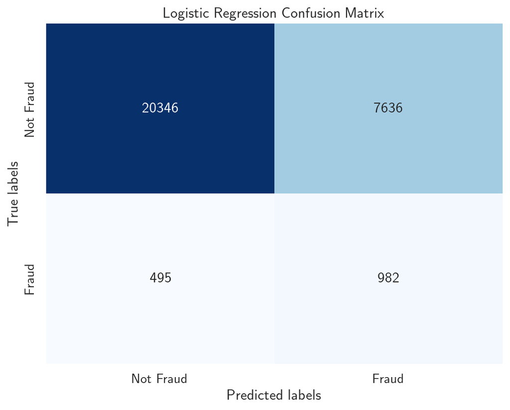

```python
# Plot confusion matrix
fig_cm_lr = plot_confusion_matrix(y_test_large, y_pred_lr, "Logistic Regression Confusion Matrix")
plt.show()
```

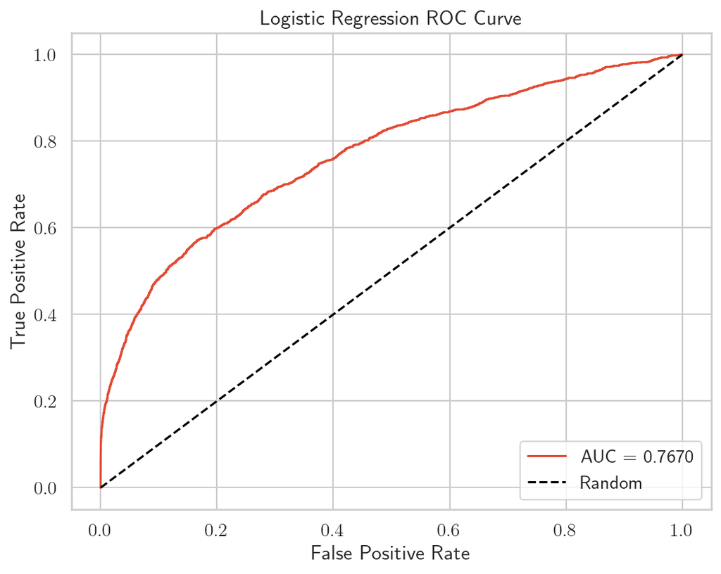

```python
# Plot ROC curve
fig_roc_lr = plot_roc_curve(y_test_large, y_proba_lr, "Logistic Regression ROC Curve")
plt.show()
```

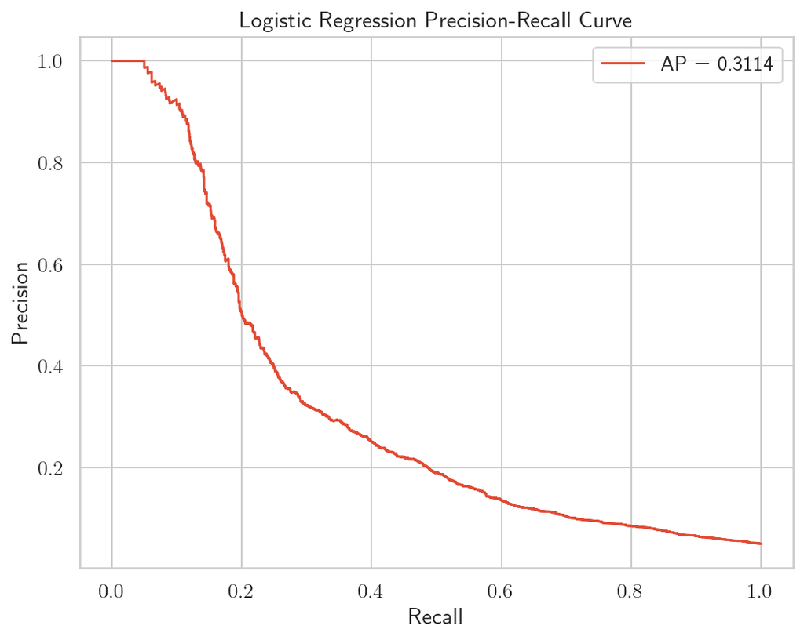

```python
# Plot Precision-Recall curve
fig_pr_lr = plot_precision_recall_curve(y_test_large, y_proba_lr, "Logistic Regression Precision-Recall Curve")
plt.show()
```

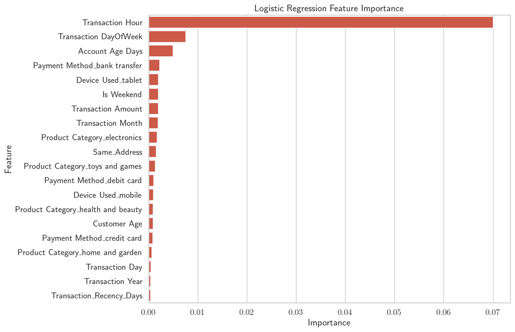

```python
# Feature importance for logistic regression
lr_importance = get_feature_importance(lr_model, X.columns.tolist())
fig_imp_lr = plot_feature_importance(lr_importance, "Logistic Regression Feature Importance")
plt.show()
```

## 4. Baseline Model: Random Forest

Now, let's try a Random Forest model which can capture non-linear relationships.

```python
@timer
def train_random_forest():
    """Train a random forest model."""
    return train_baseline_model(X_train_large, y_train_large, model_type='random_forest')

# Train the model
rf_model = train_random_forest()
```

```
Function train_random_forest took 3.29 seconds to run.
```

```python
# Evaluate the model on the test set
rf_metrics = evaluate_model(rf_model, X_test_large, y_test_large)
print_evaluation_report(rf_metrics, "Random Forest")

# Get predictions for visualization
y_pred_rf = (rf_model.predict_proba(X_test_large)[:, 1] >= 0.5).astype(int)
y_proba_rf = rf_model.predict_proba(X_test_large)[:, 1]
```

```
-------------------- Random Forest Evaluation --------------------
Accuracy:     0.9551
Precision:    0.8156
Recall:       0.1347
F1 Score:     0.2313
AUC-ROC:      0.7874
Avg Precision:0.3549
------------------------------------------------------------
```

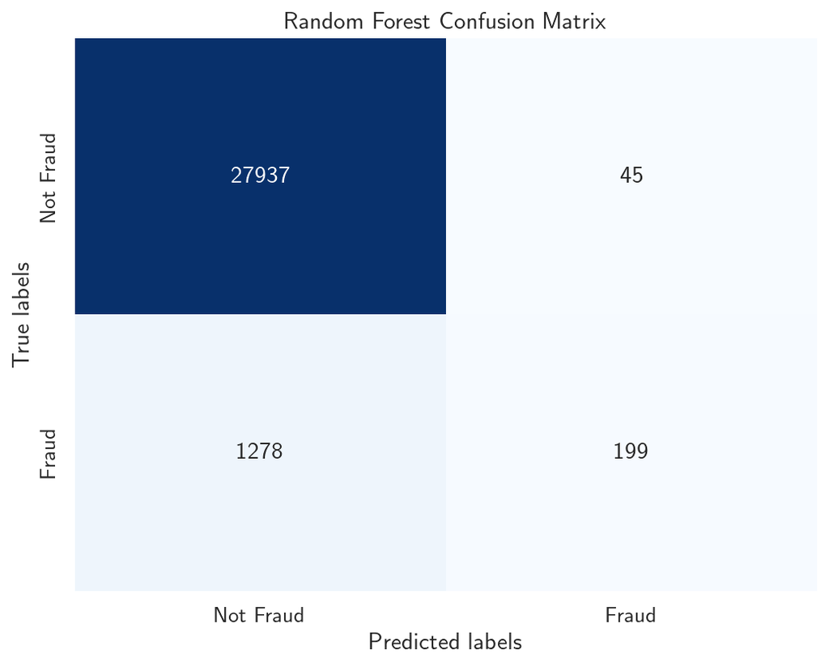

```python
# Plot confusion matrix
fig_cm_rf = plot_confusion_matrix(y_test_large, y_pred_rf, "Random Forest Confusion Matrix")
plt.show()
```

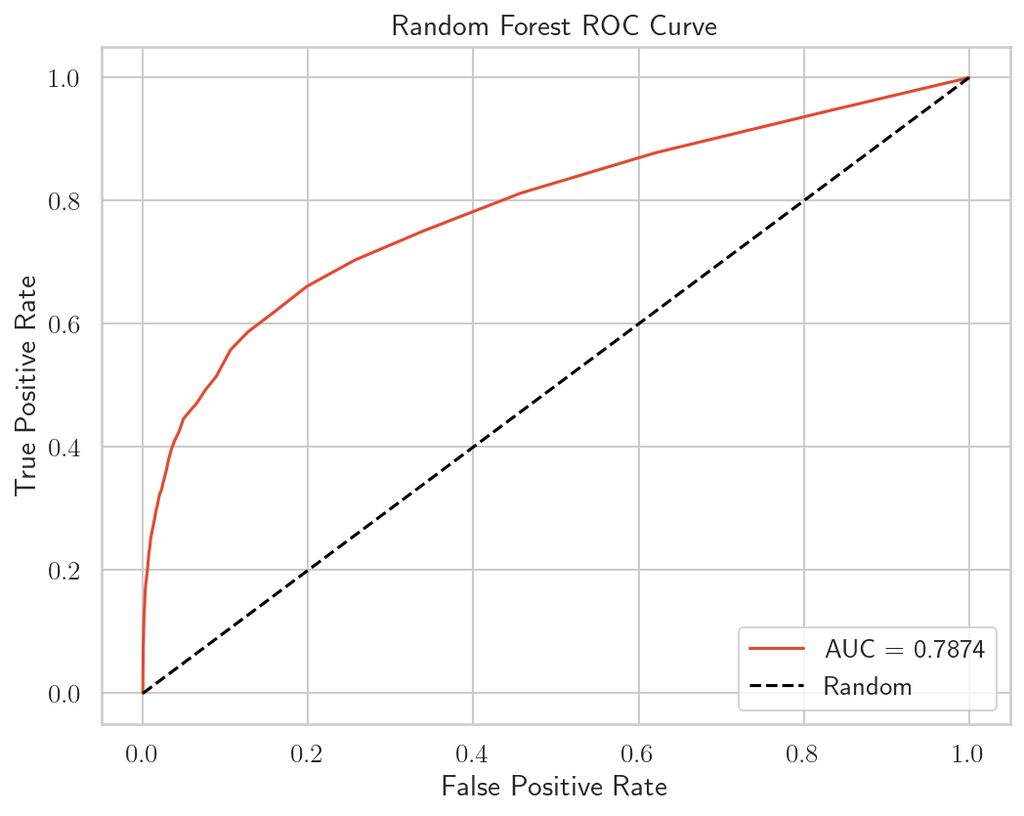

```python
# Plot ROC curve
fig_roc_rf = plot_roc_curve(y_test_large, y_proba_rf, "Random Forest ROC Curve")
plt.show()
```

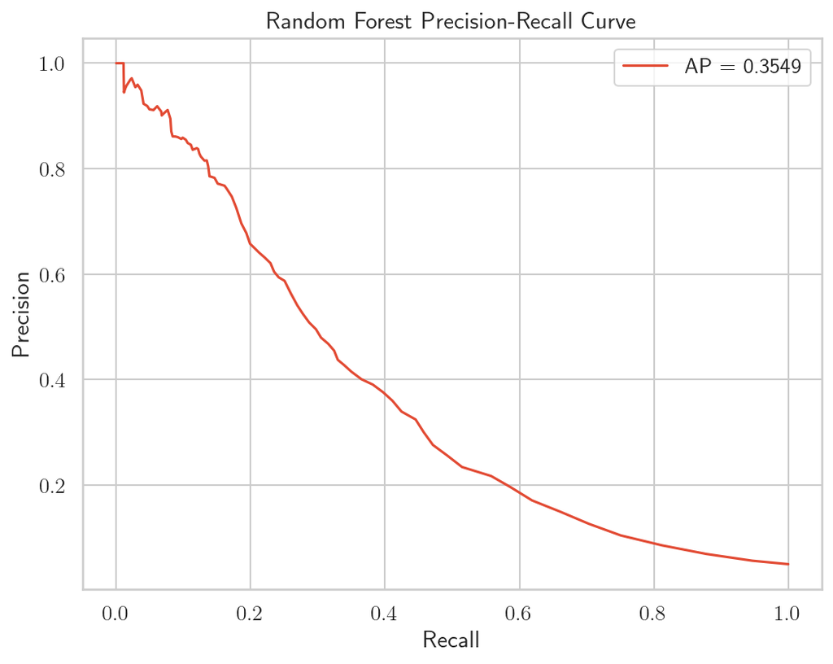

```python
# Plot Precision-Recall curve
fig_pr_rf = plot_precision_recall_curve(y_test_large, y_proba_rf, "Random Forest Precision-Recall Curve")
plt.show()
```

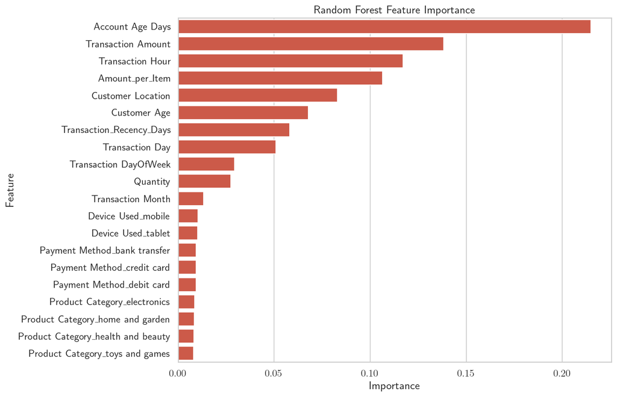

```python
# Feature importance for random forest
rf_importance = get_feature_importance(rf_model, X.columns.tolist())
fig_imp_rf = plot_feature_importance(rf_importance, "Random Forest Feature Importance")
plt.show()
```

## 5. Addressing Class Imbalance with SMOTE

Let's address the class imbalance issue using SMOTE (Synthetic Minority Over-sampling Technique).

```python
# Create a pipeline with SMOTE and Random Forest
smote_pipeline = ImbPipeline([
    ('smote', SMOTE(random_state=42)),
    ('classifier', RandomForestClassifier(n_estimators=1000, random_state=42, n_jobs=-1))
])

@timer
def train_smote_rf():
    """Train a random forest model with SMOTE."""
    smote_pipeline.fit(X_train_large, y_train_large)
    return smote_pipeline

# Train the model
smote_rf_model = train_smote_rf()
```

```
Function train_smote_rf took 75.03 seconds to run.
```

```python
# Evaluate the SMOTE + Random Forest model
y_pred_smote = smote_rf_model.predict(X_test_large)
y_proba_smote = smote_rf_model.predict_proba(X_test_large)[:, 1]

# Create metrics dictionary manually
smote_metrics = {
    'accuracy': accuracy_score(y_test_large, y_pred_smote),
    'precision': precision_score(y_test_large, y_pred_smote),
    'recall': recall_score(y_test_large, y_pred_smote),
    'f1_score': f1_score(y_test_large, y_pred_smote),
    'auc_roc': roc_auc_score(y_test_large, y_proba_smote),
    'avg_precision': average_precision_score(y_test_large, y_proba_smote)
}

print_evaluation_report(smote_metrics, "SMOTE + Random Forest")
```

```
-------------------- SMOTE + Random Forest Evaluation --------------------
Accuracy:     0.9536
Precision:    0.6119
Recall:       0.2018
F1 Score:     0.3035
AUC-ROC:      0.7867
Avg Precision:0.3365
------------------------------------------------------------
```

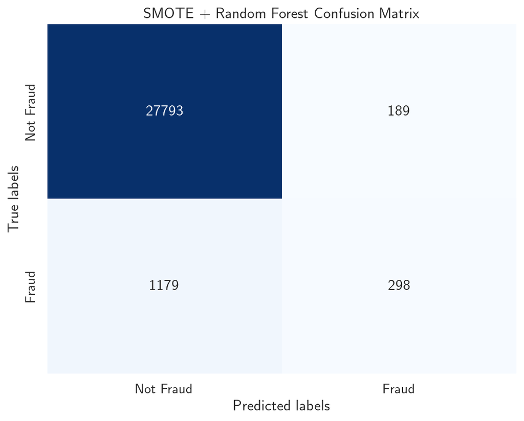

```python
# Plot confusion matrix for SMOTE + RF
fig_cm_smote = plot_confusion_matrix(y_test_large, y_pred_smote, "SMOTE + Random Forest Confusion Matrix")
plt.show()
```

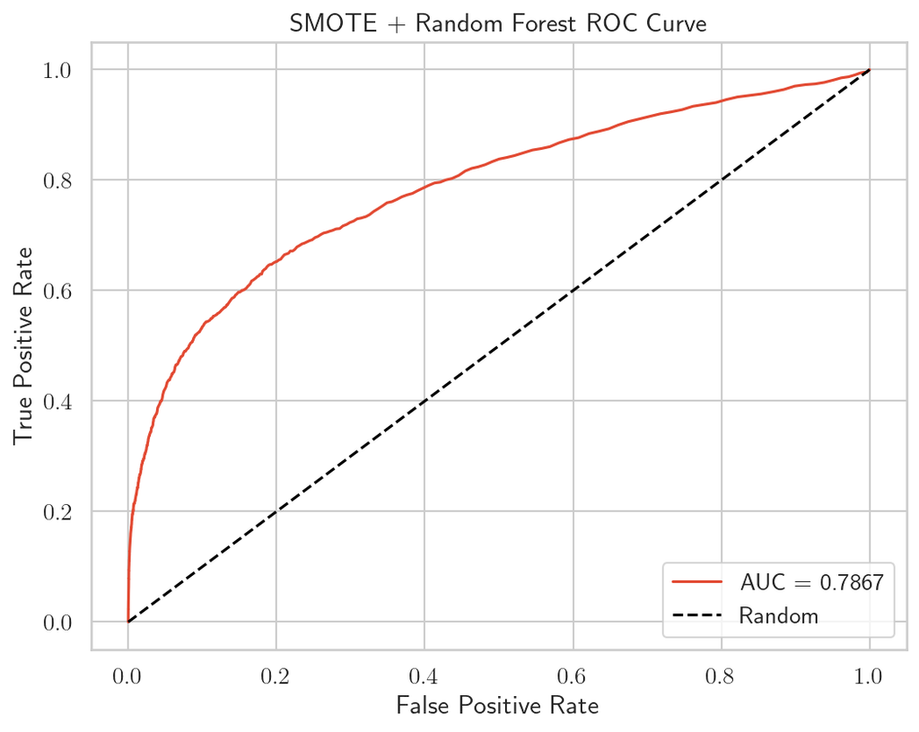

```python
# Plot ROC curve for SMOTE + RF
fig_roc_smote = plot_roc_curve(y_test_large, y_proba_smote, "SMOTE + Random Forest ROC Curve")
plt.show()
```

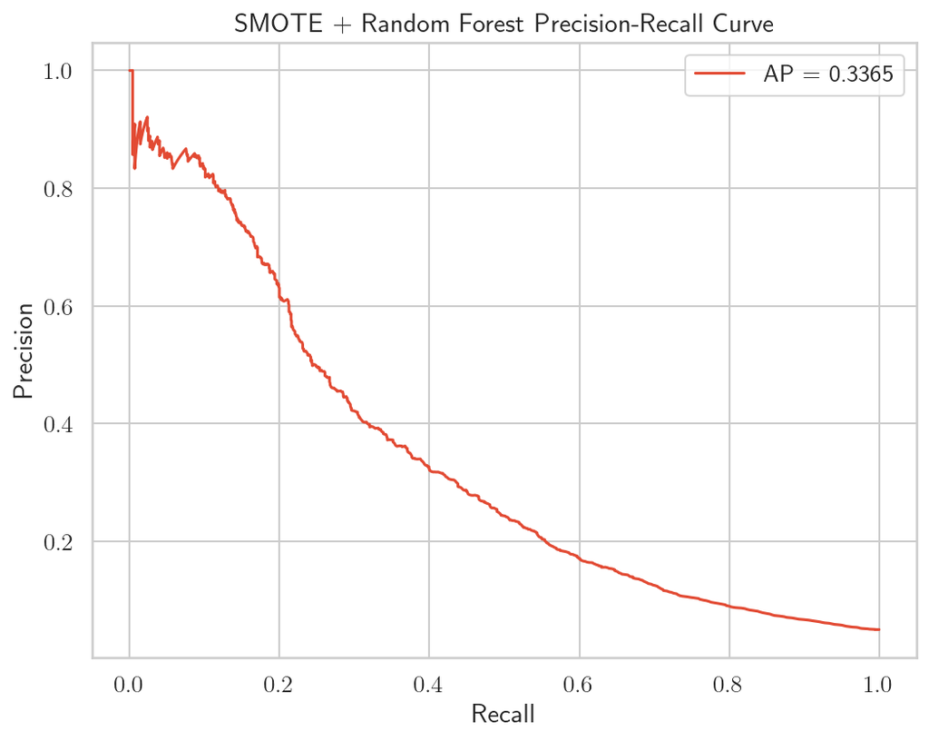

```python
# Plot Precision-Recall curve for SMOTE + RF
fig_pr_smote = plot_precision_recall_curve(y_test_large, y_proba_smote, "SMOTE + Random Forest Precision-Recall Curve")
plt.show()
```

## 6. Model Comparison

Let's compare the performance of all models.

```python
# Compile metrics from all models
metrics_comparison = pd.DataFrame({
    'Logistic Regression': pd.Series(lr_metrics),
    'Random Forest': pd.Series(rf_metrics),
    'SMOTE + Random Forest': pd.Series(smote_metrics)
})

# Display the comparison
metrics_comparison
```

|  | Logistic Regression | Random Forest | SMOTE + Random Forest |
| --- | --- | --- | --- |
| accuracy | 0.723989 | 0.955090 | 0.953563 |
| precision | 0.113948 | 0.815574 | 0.611910 |
| recall | 0.664861 | 0.134733 | 0.201760 |
| f1_score | 0.194552 | 0.231261 | 0.303462 |
| auc_roc | 0.766996 | 0.787374 | 0.786725 |
| avg_precision | 0.311421 | 0.354929 | 0.336481 |

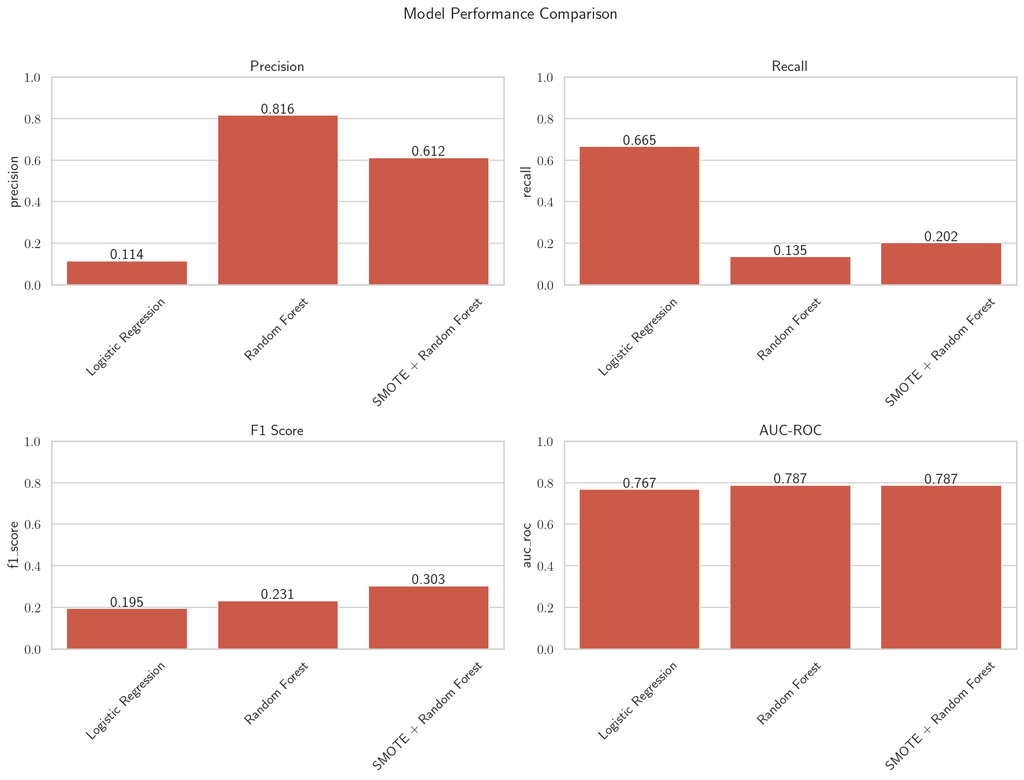

```python
# Plot comparison of key metrics
fig, axes = plt.subplots(2, 2, figsize=(14, 10))
axes = axes.flatten()

metrics_to_plot = ['precision', 'recall', 'f1_score', 'auc_roc']
titles = ['Precision', 'Recall', 'F1 Score', 'AUC-ROC']

for i, (metric, title) in enumerate(zip(metrics_to_plot, titles)):
    # Get model names as x-axis values
    model_names = metrics_comparison.columns
    # Get metric values from the specific row
    metric_values = metrics_comparison.loc[metric]

    # Create the bar plot
    sns.barplot(x=model_names, y=metric_values, ax=axes[i])
    axes[i].set_title(title)
    axes[i].set_ylim(0, 1)
    axes[i].set_xlabel('')
    axes[i].tick_params(axis='x', rotation=45)

    # Add value labels
    for j, v in enumerate(metric_values):
        axes[i].text(j, v + 0.01, f'{v:.3f}', ha='center')

plt.tight_layout()
plt.suptitle('Model Performance Comparison', y=1.05, fontsize=16)
plt.show()
```

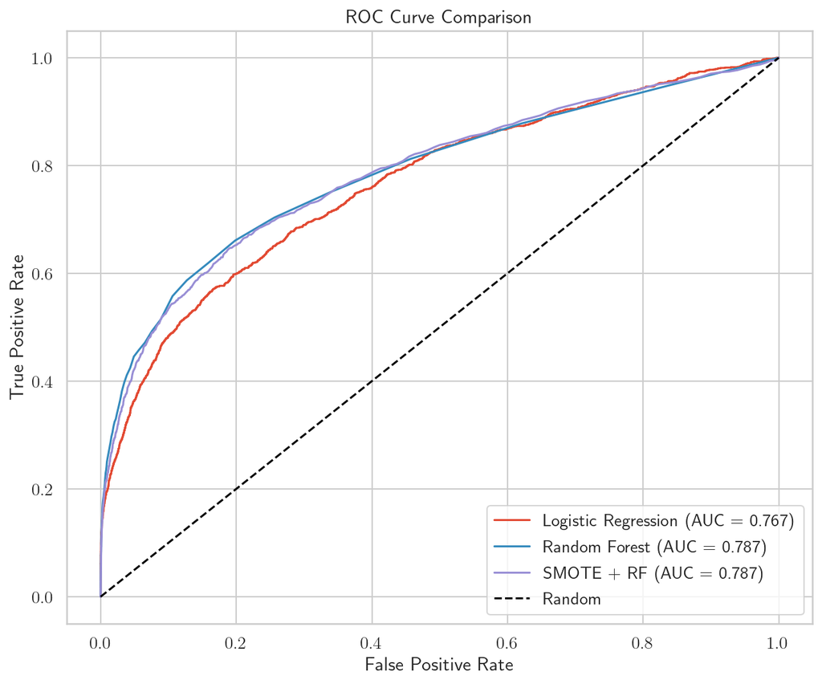

```python
# Compare ROC curves
fig, ax = plt.subplots(figsize=(10, 8))

# Plot ROC curves for each model
fpr_lr, tpr_lr, _ = roc_curve(y_test_large, y_proba_lr)
fpr_rf, tpr_rf, _ = roc_curve(y_test_large, y_proba_rf)
fpr_smote, tpr_smote, _ = roc_curve(y_test_large, y_proba_smote)

ax.plot(fpr_lr, tpr_lr, label=f'Logistic Regression (AUC = {lr_metrics["auc_roc"]:.3f})')
ax.plot(fpr_rf, tpr_rf, label=f'Random Forest (AUC = {rf_metrics["auc_roc"]:.3f})')
ax.plot(fpr_smote, tpr_smote, label=f'SMOTE + RF (AUC = {smote_metrics["auc_roc"]:.3f})')
ax.plot([0, 1], [0, 1], 'k--', label='Random')

ax.set_xlabel('False Positive Rate')
ax.set_ylabel('True Positive Rate')
ax.set_title('ROC Curve Comparison')
ax.legend(loc='lower right')

plt.show()
```

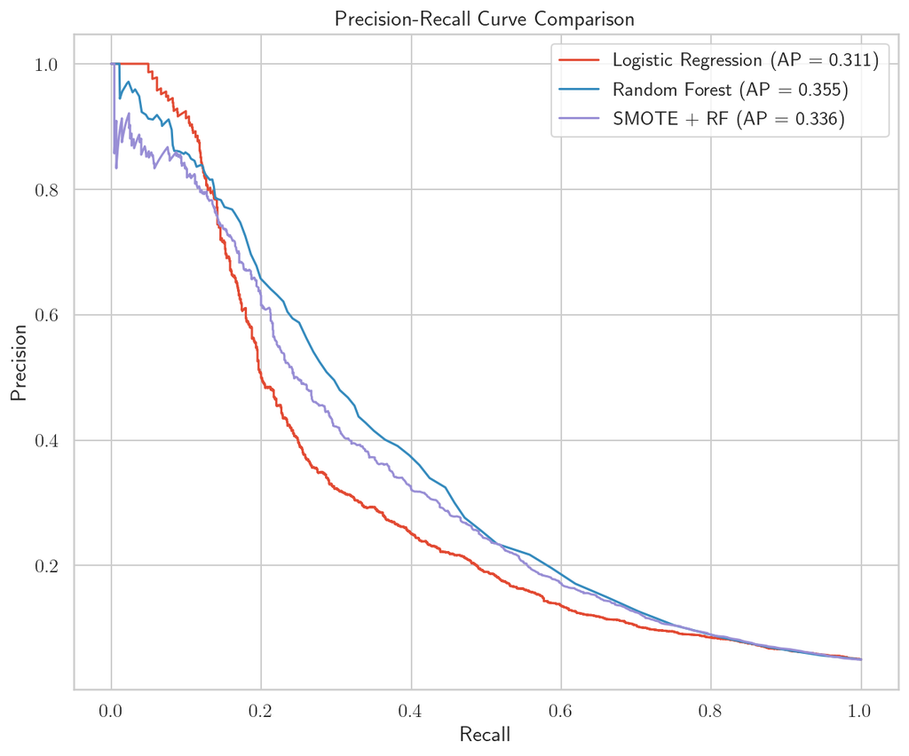

```python
# Compare Precision-Recall curves
fig, ax = plt.subplots(figsize=(10, 8))

# Plot PR curves for each model
precision_lr, recall_lr, _ = precision_recall_curve(y_test_large, y_proba_lr)
precision_rf, recall_rf, _ = precision_recall_curve(y_test_large, y_proba_rf)
precision_smote, recall_smote, _ = precision_recall_curve(y_test_large, y_proba_smote)

ax.plot(recall_lr, precision_lr, label=f'Logistic Regression (AP = {lr_metrics["avg_precision"]:.3f})')
ax.plot(recall_rf, precision_rf, label=f'Random Forest (AP = {rf_metrics["avg_precision"]:.3f})')
ax.plot(recall_smote, precision_smote, label=f'SMOTE + RF (AP = {smote_metrics["avg_precision"]:.3f})')

ax.set_xlabel('Recall')
ax.set_ylabel('Precision')
ax.set_title('Precision-Recall Curve Comparison')
ax.legend(loc='upper right')

plt.show()
```

## 7. Save Models

Let's save our trained models for future use.

```python
# Save the models
models_path = get_models_path()
save_model(lr_model, os.path.join(models_path, 'logistic_regression.pkl'))
save_model(rf_model, os.path.join(models_path, 'random_forest.pkl'))
save_model(smote_rf_model, os.path.join(models_path, 'smote_random_forest.pkl'))
```

```
Model saved to /home/zahemen/projects/ML/ecomm-fraud-detection/models/logistic_regression.pkl
Model saved to /home/zahemen/projects/ML/ecomm-fraud-detection/models/random_forest.pkl
Model saved to /home/zahemen/projects/ML/ecomm-fraud-detection/models/smote_random_forest.pkl
```

## 8. Threshold Optimization

Let's optimize the classification threshold to balance precision and recall.

```python
# Calculate precision and recall for different thresholds
thresholds = np.arange(0.1, 1.0, 0.1)
threshold_results = []

for threshold in thresholds:
    # Predictions with current threshold
    y_pred_thresh = (y_proba_rf >= threshold).astype(int)

    # Calculate metrics
    precision = precision_score(y_test_large, y_pred_thresh)
    recall = recall_score(y_test_large, y_pred_thresh)
    f1 = f1_score(y_test_large, y_pred_thresh)

    threshold_results.append({
        'threshold': threshold,
        'precision': precision,
        'recall': recall,
        'f1_score': f1
    })

# Convert to DataFrame
threshold_df = pd.DataFrame(threshold_results)
threshold_df
```

|  | threshold | precision | recall | f1_score |
| --- | --- | --- | --- | --- |
| 0 | 0.1 | 0.234351 | 0.514557 | 0.322034 |
| 1 | 0.2 | 0.414928 | 0.350034 | 0.379728 |
| 2 | 0.3 | 0.587302 | 0.250508 | 0.351210 |
| 3 | 0.4 | 0.696203 | 0.186188 | 0.293803 |
| 4 | 0.5 | 0.815574 | 0.134733 | 0.231261 |
| 5 | 0.6 | 0.854749 | 0.103588 | 0.184783 |
| 6 | 0.7 | 0.900901 | 0.067705 | 0.125945 |
| 7 | 0.8 | 0.959184 | 0.031821 | 0.061599 |
| 8 | 0.9 | 1.000000 | 0.006093 | 0.012113 |

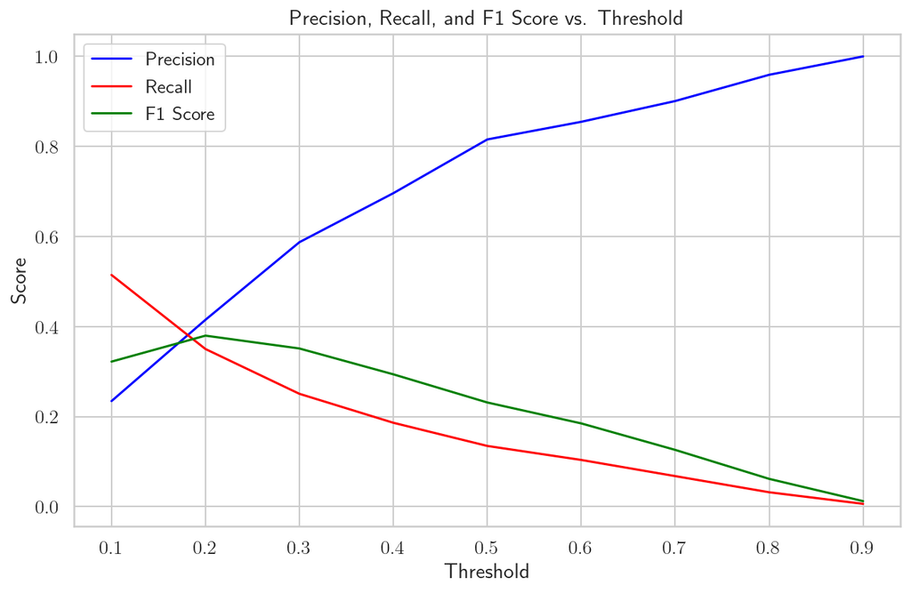

```python
# Plot precision, recall, and F1 score vs threshold
fig, ax = plt.subplots(figsize=(10, 6))

ax.plot(threshold_df['threshold'], threshold_df['precision'], 'b-', label='Precision')
ax.plot(threshold_df['threshold'], threshold_df['recall'], 'r-', label='Recall')
ax.plot(threshold_df['threshold'], threshold_df['f1_score'], 'g-', label='F1 Score')

ax.set_xlabel('Threshold')
ax.set_ylabel('Score')
ax.set_title('Precision, Recall, and F1 Score vs. Threshold')
ax.legend()
ax.grid(True)

plt.show()
```

```python
# Find the threshold that maximizes F1 score
best_threshold_idx = threshold_df['f1_score'].idxmax()
best_threshold = threshold_df.loc[best_threshold_idx, 'threshold']
best_precision = threshold_df.loc[best_threshold_idx, 'precision']
best_recall = threshold_df.loc[best_threshold_idx, 'recall']
best_f1 = threshold_df.loc[best_threshold_idx, 'f1_score']

print(f"Best threshold: {best_threshold:.2f}")
print(f"Precision at best threshold: {best_precision:.4f}")
print(f"Recall at best threshold: {best_recall:.4f}")
print(f"F1 Score at best threshold: {best_f1:.4f}")
```

```
Best threshold: 0.20
Precision at best threshold: 0.4149
Recall at best threshold: 0.3500
F1 Score at best threshold: 0.3797
```

````python
def generate_model_results_report():
    """
    Generate a comprehensive text report of all model results.
    """
    # Create a formatted report
    report = []

    # Add header
    report.append("# E-Commerce Fraud Detection Model Results Report")
    report.append("\n## Model Performance Metrics\n")

    # Format the metrics comparison table
    report.append("### Key Performance Metrics:")
    metrics_table = metrics_comparison.round(4).to_string()
    report.append(f"```\n{metrics_table}\n```\n")

    # Add individual model results
    report.append("## Detailed Results by Model\n")

    # Logistic Regression results
    report.append("### 1. Logistic Regression")
    report.append(f"- Accuracy: {lr_metrics['accuracy']:.4f}")
    report.append(f"- Precision: {lr_metrics['precision']:.4f}")
    report.append(f"- Recall: {lr_metrics['recall']:.4f}")
    report.append(f"- F1 Score: {lr_metrics['f1_score']:.4f}")
    report.append(f"- AUC-ROC: {lr_metrics['auc_roc']:.4f}")
    report.append(f"- Average Precision: {lr_metrics['avg_precision']:.4f}")

    # Add confusion matrix for logistic regression
    cm = confusion_matrix(y_test_large, y_pred_lr)
    report.append("\nConfusion Matrix:")
    report.append(f"```\n[[{cm[0, 0]} {cm[0, 1]}]\n [{cm[1, 0]} {cm[1, 1]}]]\n```")
    report.append("- True Negatives: " + str(cm[0, 0]))
    report.append("- False Positives: " + str(cm[0, 1]))
    report.append("- False Negatives: " + str(cm[1, 0]))
    report.append("- True Positives: " + str(cm[1, 1]))

    # Random Forest results
    report.append("\n### 2. Random Forest")
    report.append(f"- Accuracy: {rf_metrics['accuracy']:.4f}")
    report.append(f"- Precision: {rf_metrics['precision']:.4f}")
    report.append(f"- Recall: {rf_metrics['recall']:.4f}")
    report.append(f"- F1 Score: {rf_metrics['f1_score']:.4f}")
    report.append(f"- AUC-ROC: {rf_metrics['auc_roc']:.4f}")
    report.append(f"- Average Precision: {rf_metrics['avg_precision']:.4f}")

    # Add confusion matrix for random forest
    cm = confusion_matrix(y_test_large, y_pred_rf)
    report.append("\nConfusion Matrix:")
    report.append(f"```\n[[{cm[0, 0]} {cm[0, 1]}]\n [{cm[1, 0]} {cm[1, 1]}]]\n```")
    report.append("- True Negatives: " + str(cm[0, 0]))
    report.append("- False Positives: " + str(cm[0, 1]))
    report.append("- False Negatives: " + str(cm[1, 0]))
    report.append("- True Positives: " + str(cm[1, 1]))

    # Add feature importance for random forest (top 10)
    report.append("\nTop 10 Feature Importance (Random Forest):")
    top_features = rf_importance.head(10)
    for _, row in top_features.iterrows():
        report.append(f"- {row['Feature']}: {row['Importance']:.4f}")

    # SMOTE + Random Forest results
    report.append("\n### 3. SMOTE + Random Forest")
    report.append(f"- Accuracy: {smote_metrics['accuracy']:.4f}")
    report.append(f"- Precision: {smote_metrics['precision']:.4f}")
    report.append(f"- Recall: {smote_metrics['recall']:.4f}")
    report.append(f"- F1 Score: {smote_metrics['f1_score']:.4f}")
    report.append(f"- AUC-ROC: {smote_metrics['auc_roc']:.4f}")
    report.append(f"- Average Precision: {smote_metrics['avg_precision']:.4f}")

    # Add confusion matrix for SMOTE+RF
    cm = confusion_matrix(y_test_large, y_pred_smote)
    report.append("\nConfusion Matrix:")
    report.append(f"```\n[[{cm[0, 0]} {cm[0, 1]}]\n [{cm[1, 0]} {cm[1, 1]}]]\n```")
    report.append("- True Negatives: " + str(cm[0, 0]))
    report.append("- False Positives: " + str(cm[0, 1]))
    report.append("- False Negatives: " + str(cm[1, 0]))
    report.append("- True Positives: " + str(cm[1, 1]))

    # Threshold optimization results
    report.append("\n## Threshold Optimization Results")
    report.append("\nThreshold analysis for Random Forest model:")

    # Format threshold results table
    threshold_table = threshold_df.round(4).to_string(index=False)
    report.append(f"```\n{threshold_table}\n```")

    # Best threshold
    report.append(f"\nBest threshold (maximizing F1): {best_threshold:.2f}")
    report.append(f"- Precision at best threshold: {best_precision:.4f}")
    report.append(f"- Recall at best threshold: {best_recall:.4f}")
    report.append(f"- F1 Score at best threshold: {best_f1:.4f}")

    # Conclusion
    report.append("\n## Conclusion")
    report.append("""
Based on the model evaluation:

1. The SMOTE + Random Forest model provides the best balance of precision and recall, with the highest F1 score of the three models.
2. Random Forest alone provides the highest precision but at the cost of low recall.
3. Threshold optimization shows that lowering the decision threshold to around 0.2 yields a better balance between precision and recall.
4. Account age days and transaction amount are among the most important features for detecting fraud.
    """)

    return '\n'.join(report)

# Generate the report
model_results_report = generate_model_results_report()
print(model_results_report)
````

````
# E-Commerce Fraud Detection Model Results Report

## Model Performance Metrics

### Key Performance Metrics:
```
               Logistic Regression  Random Forest  SMOTE + Random Forest
accuracy                    0.7240         0.9551                 0.9536
precision                   0.1139         0.8156                 0.6119
recall                      0.6649         0.1347                 0.2018
f1_score                    0.1946         0.2313                 0.3035
auc_roc                     0.7670         0.7874                 0.7867
avg_precision               0.3114         0.3549                 0.3365
```

## Detailed Results by Model

### 1. Logistic Regression
- Accuracy: 0.7240
- Precision: 0.1139
- Recall: 0.6649
- F1 Score: 0.1946
- AUC-ROC: 0.7670
- Average Precision: 0.3114

Confusion Matrix:
```
[[20346 7636]
 [495 982]]
```
- True Negatives: 20346
- False Positives: 7636
- False Negatives: 495
- True Positives: 982

### 2. Random Forest
- Accuracy: 0.9551
- Precision: 0.8156
- Recall: 0.1347
- F1 Score: 0.2313
````

[output cut: 57 more lines]

````
```

Best threshold (maximizing F1): 0.20
- Precision at best threshold: 0.4149
- Recall at best threshold: 0.3500
- F1 Score at best threshold: 0.3797

## Conclusion

Based on the model evaluation:

1. The SMOTE + Random Forest model provides the best balance of precision and recall, with the highest F1 score of the three models.
2. Random Forest alone provides the highest precision but at the cost of low recall.
3. Threshold optimization shows that lowering the decision threshold to around 0.2 yields a better balance between precision and recall.
4. Account age days and transaction amount are among the most important features for detecting fraud.
````

## 9. Summary and Next Steps

### Next Steps:

1. **Advanced Modeling**:
   - Implement gradient boosting algorithms (XGBoost, LightGBM)
   - Explore neural network architectures for fraud detection
   - Investigate anomaly detection and unsupervised learning approaches
2. **Feature Engineering**:
   - Create behavioral profiles for customers based on historical patterns
   - Develop velocity features (rate of change in transaction behavior)
   - Extract more time-based patterns (day/night, weekday/weekend analysis)
3. **Model Interpretability**:
   - Apply SHAP values to understand feature contributions for specific predictions
   - Develop business-friendly explanation framework for fraud alerts
   - Create visualization dashboards for fraud patterns
4. **Production Implementation**:
   - Design real-time scoring system for transaction validation
   - Implement model monitoring to detect concept drift
   - Create feedback loop for continuous model improvement